# Tests of Significance

The 95% confidence interval chosen in the previous example is no coincidence, it is a conventional criterium for statistical significance within the social sciences (other fields have other accuracy requirements and therefore different values). In a frequentist framework, a result is generally considered significant (reliable) if the probability of it being random is less than 5%, or roughly two standard deviations.

How likely is it that a difference in mean of samples from two groups actually represents different means of the population? How likely is it that these differences are just the result of chance?

Using the MPG dataset, we wil compare

- Fuel consumption by transmission type
- Fuel consumption by drive

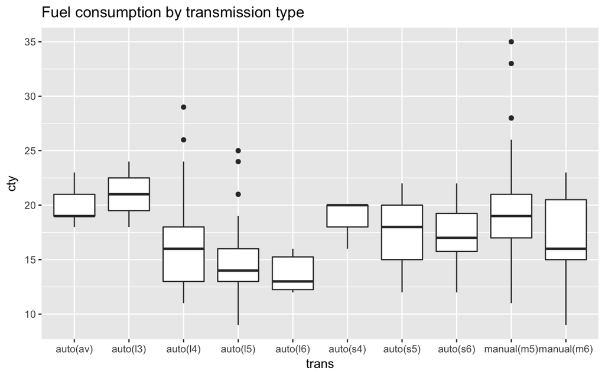

```r
ggplot(mpg, aes(y=cty, x = trans)) + geom_boxplot() + ggtitle("Fuel consumption by transmission type")
```

There seem to be big differences. But can we be sure that the differences are not just sampling errors? Let’s look at the means and 95% confidence intervals.

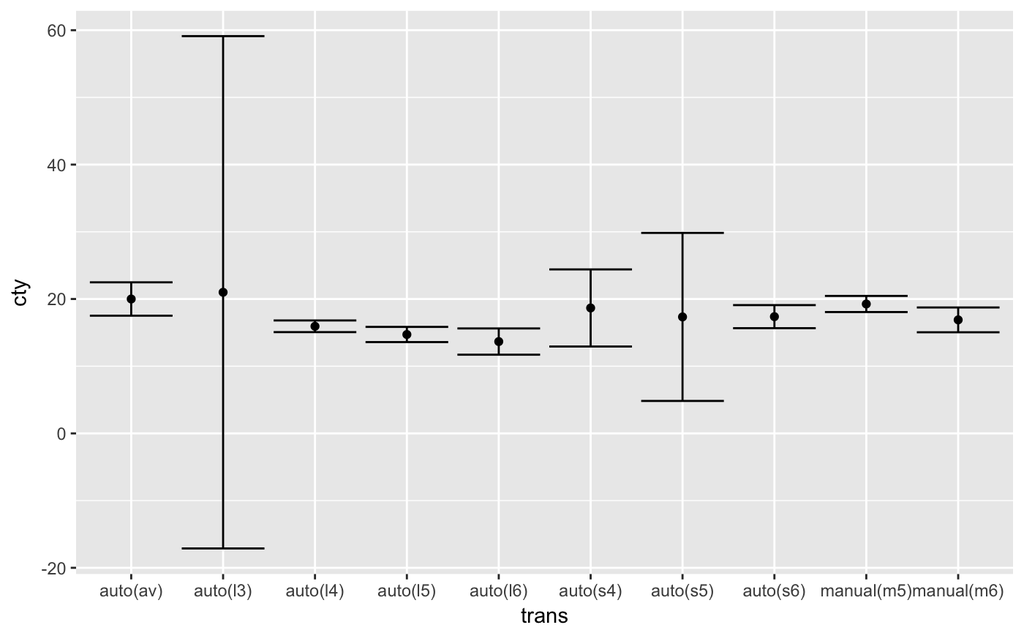

```r
# the mean_cl_normal function (package Hmisc) calculates confidence 95% intervals (and others if specified)
ggplot(mpg, aes(y=cty, x = trans)) + stat_summary(fun.data = mean_cl_normal, geom = "errorbar") +
stat_summary(fun.y = mean, geom = "point")
```

A large overlap of CIs, therefore we cannot rule out that the differences are just due to chance / sampling errors. Compare that with the differences grouped by drive. Here, the differences are quite clear.

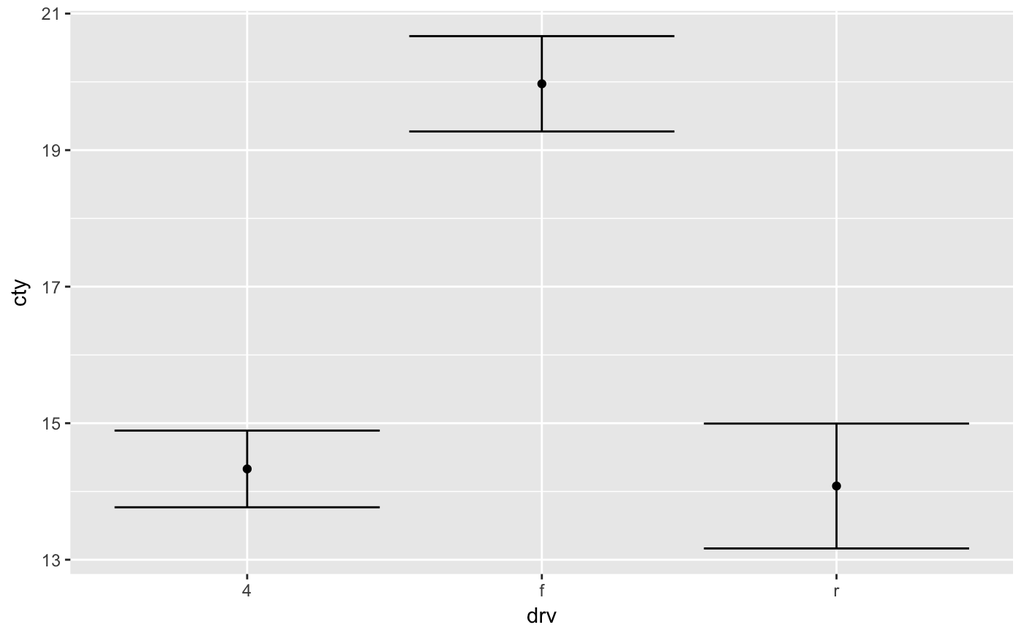

```r
ggplot(mpg, aes(y=cty, x = drv)) + stat_summary(fun.data = mean_cl_normal, geom = "errorbar") +
stat_summary(fun.y = mean, geom = "point")
```

Let’s calculate it manually. There are a few advanced techniques here - aggregating a data set by a variable, and applying a number of functions to the groups. This gives us a table of summary statistics containing the mean, standard error, confidence intervals, and size of the sample.

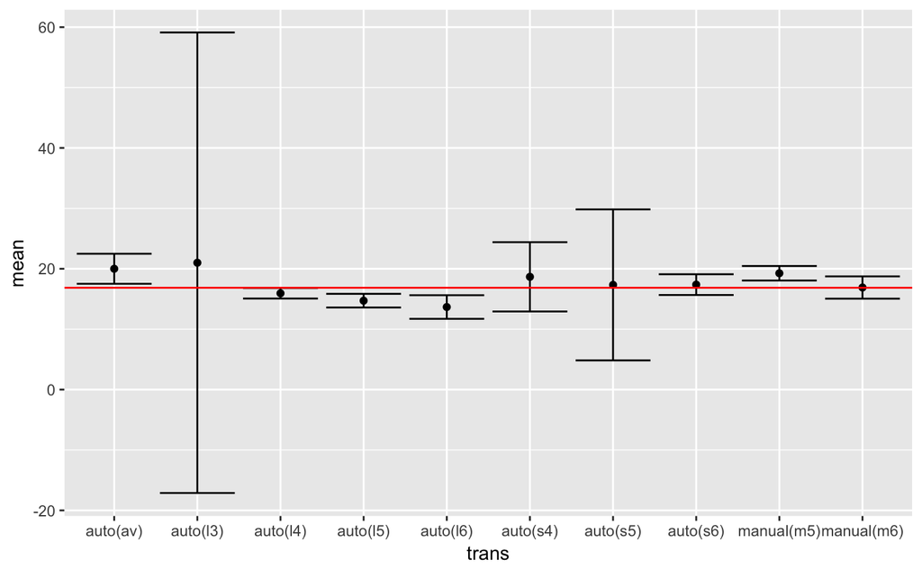

```r
# let's calcualate it manually
# pick the two relevant columns - consumption in city, type of transmission
transm <- data.frame(cty = mpg$cty, trans = mpg$trans)
# population mean
m.pop <- mean(mpg$cty)
m.se <- sd(mpg$cty)/sqrt(length(mpg$cty))
# a function to calculate 95% CIs using the t-distribution
ci <- function(x) qt(0.975,df = length(x)-1)*sd(x)/sqrt(length(x))
# aggregate data and apply functions - mean, standard error, CIs
tr <- aggregate(data = transm,
                . ~ trans,
                FUN = function(x) c(mean = mean(x),
                                    se = sd(x)/sqrt(length(x)),
                                    ci.l = mean(x) - ci(x),
                                    ci.h = mean(x) + ci(x),
                                    n = length(x)))
# str(dr) shows that result is nested
# unnest the resulting data structure
t <- as.data.frame(tr$cty)
tr <- data.frame(trans=tr$trans, t)
# now we plot it and superimpose the population mean
ggplot(tr,aes(x=trans, y = mean)) +
  geom_point() +
  geom_errorbar(aes(ymin=ci.l, ymax=ci.h)) +
  geom_hline(yintercept = m.pop, color = "red")
```

```r
# calculate t values
# is mean(front wheel) and mean(4-wheel) significantly different?
# t = (sample mean - population mean) / standard error estimate
t <- (tr$mean - m.pop) / tr$se
t
```

```
 [1]  3.5117734  1.3803419 -2.1059288 -3.8350691 -4.1997586  1.3557692  0.1632381  0.6405645  4.0045270  0.0407204
```

```r
# is the probability that the sample mean is equal the population mean smaller than 5%?
# we use the t-distribution to get the p-value for a particular t-score
# we want the probability that our value is significantly different, i.e. outside the 95% CI
# because t-dist is symmetric and t-scores can be negative, we use the absolute value
1-pt(abs(t),df=tr$n-1) < 0.05
```

```
 [1]  TRUE FALSE  TRUE  TRUE  TRUE FALSE FALSE FALSE  TRUE FALSE
```